# BUISNESS CASE: WITH THE FIFA20 DATASET WE NEED TO CLUSTER THE PLAYER BY THEIR SKILL INTO CERTAIN GROUP

# 3.HANDLING CATEGORICAL DATA

In this data only preferred foot and team position feature is impoertant and remaining all feature is unique.

1.PREFERRED FOOT

```python
# Gettimg value counts of preferred foot
data.preferred_foot.value_counts()
```

```
preferred_foot
Right    13960
Left      4318
Name: count, dtype: int64
```

```python
# right is assign with 1 because of majority and most freqent
# left is assign with 0 because of less no
data.preferred_foot = data.preferred_foot.map({'Right':1,'Left':0})
```

2.TEAM POSITION

```python
# Getting the value counts of team position
data.team_position.value_counts()
```

```
team_position
SUB    8060
RES    2958
GK      662
RCB     660
LCB     660
RB      560
LB      560
ST      458
RCM     411
LCM     411
RM      399
LM      398
CAM     311
RDM     244
LDM     242
RS      195
LS      195
CDM     181
LW      162
RW      161
CB      100
CM       76
RWB      58
LWB      58
RAM      23
LAM      23
RF       19
LF       19
CF       14
Name: count, dtype: int64
```

```python
# Use mannual encoding because lots of labels avialble
data.team_position = data.team_position.map({'SUB':28,'RES':27,'GK':26,'RCB':25,'LCB':24,'RB':23,'LB':22,'ST':21,
                                            'RCM':20,'LCM':19,'RM':18,'LM':17,'CAM':16,'RDM':15,'LDM':14,'RS':13,
                                            'LS':12,'CDM':11,'LW':10,'RW':9,'CB':8,'CM':7,'RWB':6,'LWB':5,'RAM':4,
                                            'LAM':3,'RF':2,'LF':1,'CF':0})
```

```python
data.team_position.unique()
```

```
array([ 9, 10, 16, 26, 20, 24, 21, 11, 14, 18, 25, 19, 17,  0, 28, 22, 12,
       23, 15, 27,  4, 13,  2,  7,  8,  1,  3,  6,  5])
```

4.OUTLIER HANDLING

In this data we are handle only important feature outlier, because the remaining feature is unique or some feature is not reuired to handle outlier

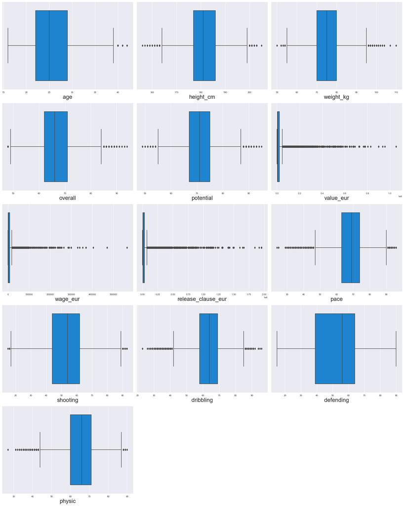

```python
out = data[['age','height_cm','weight_kg','overall','potential','value_eur','wage_eur','release_clause_eur','pace',
           'shooting','dribbling','defending','physic']]

plt.figure(figsize=(20,25)) # defining canvas size
plotno = 1 # counter

for column in out: # iteration of columns / acessing the columns from  dataset
    if plotno<=16:    # set the limit
        plt.subplot(5,3,plotno) # # plotting 12 graphs (4-rows,3-columns) ,plotnumber is for count
        sns.boxplot(x=out[column]) # Plotting box plots
        plt.xlabel(column,fontsize=20)  # assigning name to x-axis and font size is 20
    plotno+=1 # counter increment
plt.tight_layout()
plt.show() # used to hide the storage loction
```

CHECKING THE DISTRIBUTION BEFORE HANDLE THE OUTLIER

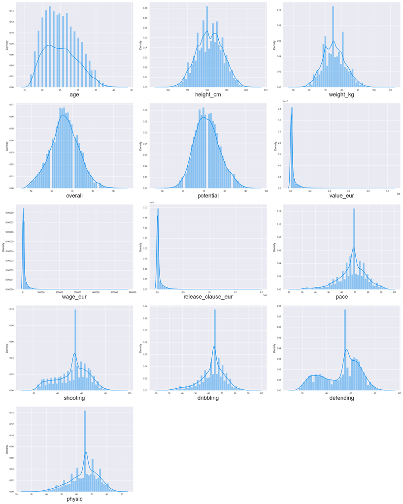

```python
dist1 = data[['age','height_cm','weight_kg','overall','potential','value_eur','wage_eur','release_clause_eur','pace',
           'shooting','dribbling','defending','physic']]

plt.figure(figsize=(20,25)) # defining canvas size
plotno = 1 # counter

for column in dist1: # iteration of columns / acessing the columns from  dataset
    if plotno<=15:    # set the limit
        plt.subplot(5,3,plotno) # # plotting 36 graphs (9-rows,4-columns) ,plotnumber is for count
        sns.distplot(x=out[column]) # Plotting box plots
        plt.xlabel(column,fontsize=20)  # assigning name to x-axis and font size is 20
    plotno+=1 # counter increment
plt.tight_layout()
plt.show() # used to hide the storage loction
```

Here age,height_cm,weight_kg,overall,potential is follow a normal distribution so we are empherical rule and remaining feature we use iqr

1.AGE

```python
upper_limit = data.age.mean() + 3*data.age.std()
print("Upper limit:",upper_limit)
lower_limit = data.age.mean() - 3*data.age.std()
print("Lower limit:",lower_limit)
```

```
Upper limit: 39.25418488202056
Lower limit: 11.312397895088532
```

```python
# Getting the percentage of outlier
len(data.loc[data['age'] > upper_limit])/18278*100
# In age feature less than 5% outlier we are impute the outlier
```

```
0.10395010395010396
```

```python
# impute outlier with mean because feature follow a normal distribution and continous data
data.loc[data['age'] > upper_limit,'age']=data['age'].mean()
```

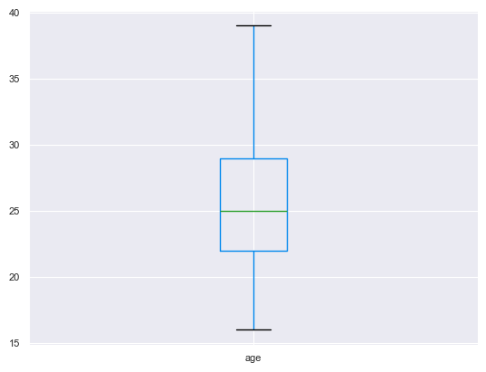

```python
data.boxplot('age')
plt.show()
```

Outlier impute successfully

2.HEIGHT CM

```python
upper_limit = data.height_cm.mean() + 3*data.height_cm.std()
print("Upper limit:",upper_limit)
lower_limit = data.height_cm.mean() - 3*data.height_cm.std()
print("Lower limit:",lower_limit)
```

```
Upper limit: 201.6330681374958
Lower limit: 161.09129995529332
```

```python
# Checking the percentage of outlier
len(data.loc[data['height_cm'] > upper_limit])/18278*100
```

```
0.06018163912900754
```

```python
# impute outlier both lower and upper side
data.loc[data['height_cm'] <  lower_limit,'height_cm'] = data['height_cm'].mean()
data.loc[data['height_cm'] > upper_limit,'height_cm'] = data['height_cm'].mean()
```

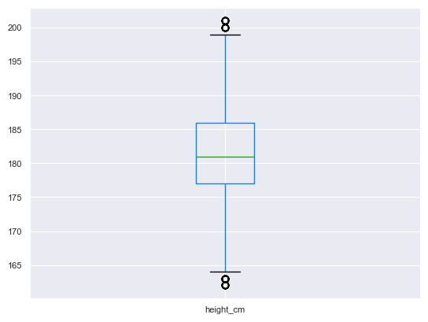

```python
data.boxplot('height_cm')
plt.show()
```

Outlier is impute but box plot are show outlier

3.WEIGHT KG

```python
upper_limit = data.weight_kg.mean() + 3*data.weight_kg.std()
print("Upper limit:",upper_limit)
lower_limit = data.weight_kg.mean() - 3*data.weight_kg.std()
print("Lower limit:",lower_limit)
```

```
Upper limit: 96.41957385582987
Lower limit: 54.13311243369853
```

```python
# Lower limit percentage
len(data.loc[data['weight_kg'] < lower_limit])/18278*100
```

```
0.06018163912900754
```

```python
# upper limit percentage
len(data.loc[data['weight_kg'] > upper_limit])/18278*100
```

```
0.22431338220811906
```

```python
# impute outlier
data.loc[data['weight_kg'] < lower_limit,'weight_kg']=data['weight_kg'].mean()
data.loc[data['weight_kg'] > upper_limit,'weight_kg']=data['weight_kg'].mean()
```

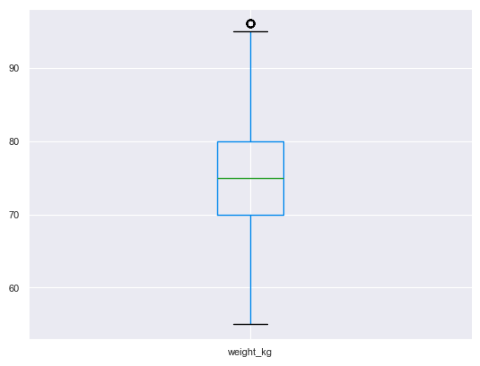

```python
data.boxplot('weight_kg')
plt.show()
```

4.OVERALL

```python
upper_limit = data.overall.mean() + 3*data.overall.std()
print("Upper limit:",upper_limit)
lower_limit = data.overall.mean() - 3*data.overall.std()
print("Lower limit:",lower_limit)
```

```
Upper limit: 87.09485374672605
Lower limit: 45.395134216946126
```

```python
data.loc[data['overall'] < lower_limit]
# no outlier in lower limit
```

|  | sofifa_id | player_url | short_name | long_name | age | dob | height_cm | weight_kg | nationality | club | overall | potential | value_eur | wage_eur | player_positions | preferred_foot | international_reputation | weak_foot | skill_moves | work_rate | body_type | real_face | release_clause_eur | player_tags | team_position | team_jersey_number | loaned_from | joined | contract_valid_until | … |
| --- | --- | --- | --- | --- | --- | --- | --- | --- | --- | --- | --- | --- | --- | --- | --- | --- | --- | --- | --- | --- | --- | --- | --- | --- | --- | --- | --- | --- | --- | --- |

```python
# Get the percentage of outlier
len(data.loc[data['overall'] > upper_limit])/18278*100
```

```
0.218842324105482
```

```python
data.loc[data['overall'] > upper_limit, 'overall'] = data['overall'].mean()
```

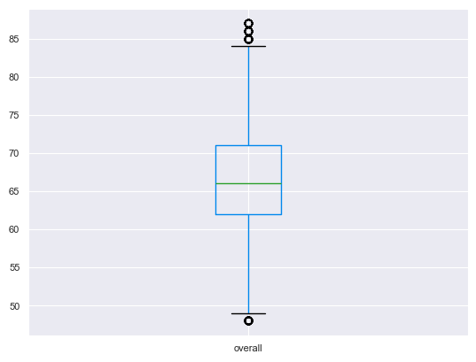

```python
data.boxplot('overall')
plt.show()
```

5.POTENTIAL

```python
upper_limit = data.potential.mean() + 3*data.potential.std()
print("Upper limit:",upper_limit)
lower_limit = data.potential.mean() - 3*data.potential.std()
print("Lower limit:",lower_limit)
```

```
Upper limit: 89.96589419280835
Lower limit: 53.12787974307086
```

```python
# Lower limit
len(data.loc[data['potential'] < lower_limit])/18278*100
```

```
0.09300798774482985
```

```python
# upperlimit
len(data.loc[data['potential'] > upper_limit])/18278*100
```

```
0.21337126600284498
```

```python
# impute outlier
data.loc[data['potential'] < lower_limit,'potential']=data['potential'].mean()
data.loc[data['potential'] > upper_limit,'potential']=data['potential'].mean()
```

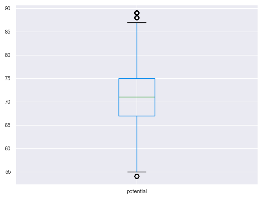

```python
data.boxplot('potential')
plt.show()
```

INRET QUATIEL RANGE (IQR)

1.VALUE EUR

```python
# Use iqr because of some right skewed in data

# Step:1
from scipy import stats
iqr = stats.iqr(data['value_eur'],interpolation='midpoint')
print("IQR",iqr)

# step:2
Q1 = data['value_eur'].quantile(0.25)  # first quantile
Q3 = data['value_eur'].quantile(0.75)  #third quantile
# getting max & min limit
min_limit = Q1 - 1.5*iqr
print('minimum limit',min_limit)
max_limit = Q3 + 1.5*iqr
print('maximum limit',max_limit)
```

```
IQR 1775000.0
minimum limit -2337500.0
maximum limit 4762500.0
```

```python
# get the percentage
len(data.loc[data['value_eur'] > max_limit])/18278*100
```

```
13.737826895721634
```

Here outlier is more than 5% so we not impute the outlier

2.WAGE EUR

```python
# Use iqr because of some right skewed in data

# Step:1
from scipy import stats
iqr = stats.iqr(data['wage_eur'],interpolation='midpoint')
print("IQR",iqr)

# step:2
Q1 = data['wage_eur'].quantile(0.25)  # first quantile
Q3 = data['wage_eur'].quantile(0.75)  #third quantile
# getting max & min limit
min_limit = Q1 - 1.5*iqr
print('minimum limit',min_limit)

max_limit = Q3 + 1.5*iqr
print('maximum limit',max_limit)
```

```
IQR 7000.0
minimum limit -9500.0
maximum limit 18500.0
```

```python
len(data.loc[data['wage_eur'] > max_limit])/18278*100
```

```
12.911697122223437
```

Here also outlier is more than 5% so we dont impute the outlier

3.RELEASE CLASUSE EUR

```python
# Use iqr because of some right skewed in data

# Step:1
from scipy import stats
iqr = stats.iqr(data['release_clause_eur'],interpolation='midpoint')
print("IQR",iqr)

# step:2
Q1 = data['release_clause_eur'].quantile(0.25)  # first quantile
Q3 = data['release_clause_eur'].quantile(0.75)  #third quantile
# getting max & min limit
min_limit = Q1 - 1.5*iqr
print('minimum limit',min_limit)
max_limit = Q3 + 1.5*iqr
print('maximum limit',max_limit)
```

```
IQR 2604000.0
minimum limit -3310000.0
maximum limit 7106000.0
```

```python
len(data.loc[data['release_clause_eur'] > max_limit])/18278*100
```

```
15.368202210307475
```

Here also outlier is more than 5% so we dont impute the outlier

4.PACE

```python
# Use iqr because of some left skewed in data

# Step:1
from scipy import stats
iqr = stats.iqr(data['pace'],interpolation='midpoint')
print("IQR",iqr)

# step:2
Q1 = data['pace'].quantile(0.25)  # first quantile
Q3 = data['pace'].quantile(0.75)  #third quantile
# getting max & min limit
min_limit = Q1 - 1.5*iqr
print('minimum limit',min_limit)
max_limit = Q3 + 1.5*iqr
print('maximum limit',max_limit)
```

```
IQR 11.0
minimum limit 46.5
maximum limit 90.5
```

```python
# min limit
len(data.loc[data['pace'] < min_limit])/18278*100
```

```
4.19083050661998
```

```python
# max limit
len(data.loc[data['pace'] > max_limit])/18278*100
```

```
1.0285589232957655
```

```python
# impute outlier both side
data.loc[data['pace'] < min_limit,'pace'] = data['pace'].median()
data.loc[data['pace'] > max_limit,'pace'] = data['pace'].median()
```

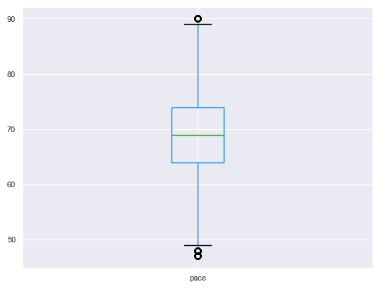

```python
# box plot after impute the outlier
data.boxplot('pace')
plt.show()
```

Outlier is impute successfully, but box plot is show outlier

5.SHOOTING

```python
# Use iqr because of some left skewed in data

# Step:1
from scipy import stats
iqr = stats.iqr(data['shooting'],interpolation='midpoint')
print("IQR",iqr)

# step:2
Q1 = data['shooting'].quantile(0.25)  # first quantile
Q3 = data['shooting'].quantile(0.75)  #third quantile
# getting max & min limit
min_limit = Q1 - 1.5*iqr
print('minimum limit',min_limit)
max_limit = Q3 + 1.5*iqr
print('maximum limit',max_limit)
```

```
IQR 18.0
minimum limit 17.0
maximum limit 89.0
```

```python
# min limit percentage
len(data.loc[data['shooting'] < min_limit])/18278*100
```

```
0.02735529051318525
```

```python
# max limit percentage
len(data.loc[data['shooting'] > max_limit])/18278*100
```

```
0.0218842324105482
```

```python
# impute the outlier
data.loc[data['shooting'] < min_limit,'shooting'] = data['shooting'].median()
data.loc[data['shooting'] > max_limit,'shooting'] = data['shooting'].median()
```

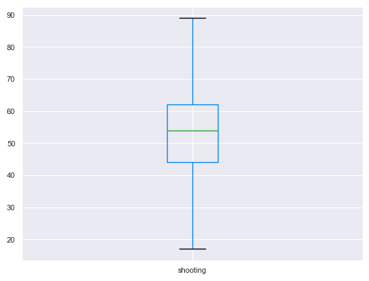

```python
# boxplot
data.boxplot('shooting')
plt.show()
```

6.DRIBBLING

```python
# Use iqr because of some left skewed in data

# Step:1
from scipy import stats
iqr = stats.iqr(data['dribbling'],interpolation='midpoint')
print("IQR",iqr)

# step:2
Q1 = data['dribbling'].quantile(0.25)  # first quantile
Q3 = data['dribbling'].quantile(0.75)  #third quantile
# getting max & min limit
min_limit = Q1 - 1.5*iqr
print('minimum limit',min_limit)
max_limit = Q3 + 1.5*iqr
print('maximum limit',max_limit)
```

```
IQR 11.0
minimum limit 41.5
maximum limit 85.5
```

```python
# min limit percentage
len(data.loc[data['shooting'] < min_limit])/18278*100
```

```
21.80763759711128
```

```python
# impute outlier
data.loc[data['dribbling'] > max_limit,'dribbling']=data['dribbling'].median()
```

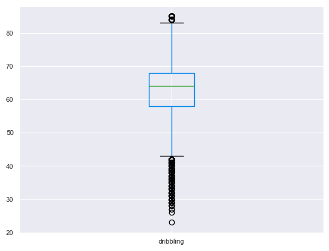

```python
# box plot
data.boxplot('dribbling')
plt.show()
```

7.PHYSIC

```python
# Use iqr because of some left skewed in data

# Step:1
from scipy import stats
iqr = stats.iqr(data['physic'],interpolation='midpoint')
print("IQR",iqr)

# step:2
Q1 = data['physic'].quantile(0.25)  # first quantile
Q3 = data['physic'].quantile(0.75)  #third quantile
# getting max & min limit
min_limit = Q1 - 1.5*iqr
print('minimum limit',min_limit)
max_limit = Q3 + 1.5*iqr
print('maximum limit',max_limit)
```

```
IQR 11.0
minimum limit 43.5
maximum limit 87.5
```

```python
# min limit percentage
len(data.loc[data['physic'] < min_limit])/18278*100
```

```
2.303315461210198
```

```python
# max limit percentage
len(data.loc[data['physic'] > max_limit])/18278*100
```

```
0.0656526972316446
```

```python
# impute outlier
data.loc[data['physic'] < min_limit,'physic']=data['physic'].median()
data.loc[data['physic'] > max_limit,'physic']=data['physic'].median()
```

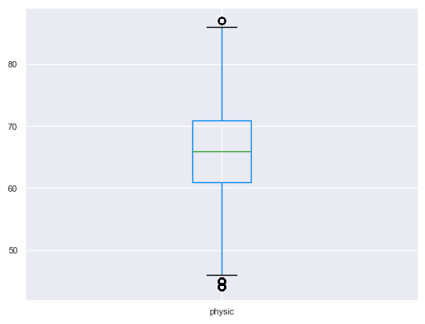

```python
# boxplot
data.boxplot('physic')
plt.show()
```

Outlier is impute successfull, this outlier is shown after impute the outlier.

CHECKING DISTRIBUTION AFTER IMPUTE OUTLIER

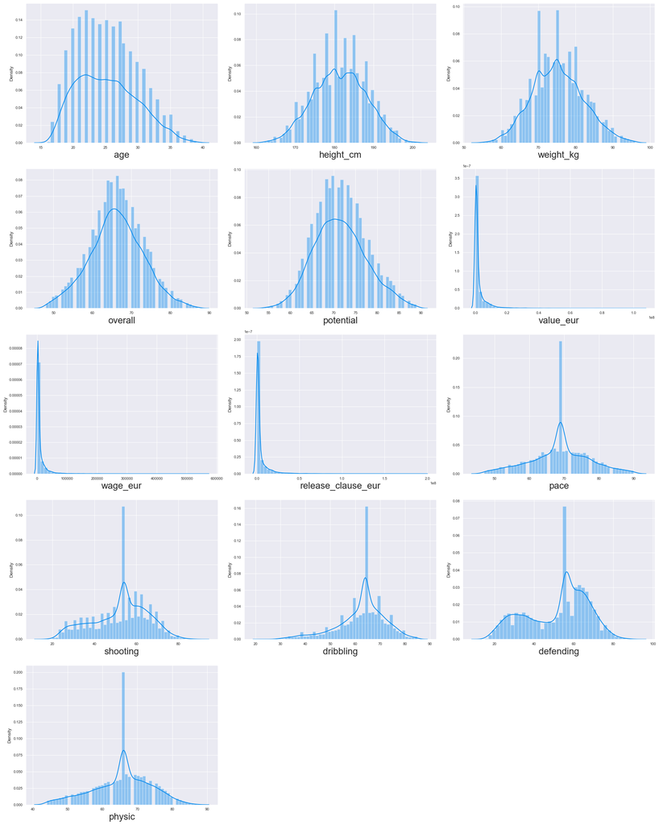

```python
dist2 = data[['age','height_cm','weight_kg','overall','potential','value_eur','wage_eur','release_clause_eur','pace',
           'shooting','dribbling','defending','physic']]

plt.figure(figsize=(20,25)) # defining canvas size
plotno = 1 # counter

for column in dist2: # iteration of columns / acessing the columns from  dataset
    if plotno<=15:    # set the limit
        plt.subplot(5,3,plotno) # # plotting 13 graphs (5-rows,3-columns) ,plotnumber is for count
        sns.distplot(x=dist2[column]) # Plotting box plots
        plt.xlabel(column,fontsize=20)  # assigning name to x-axis and font size is 20
    plotno+=1 # counter increment
plt.tight_layout()
plt.show() # used to hide the storage loction
```

# 5.FEATURE SCALING

MIN-MAX SCALING

Scale the feature between 0 t0 1 Only scale the continous feature Use min max scaling because of dataset contain large amount of outlier so outlier is going to be biased.

```python
# Scale only continous feature in nature
from sklearn.preprocessing import MinMaxScaler
scaler = MinMaxScaler() # Object Creation
data[['age','height_cm','weight_kg','overall','potential','value_eur','wage_eur','release_clause_eur',
    'pace','shooting','passing','dribbling','defending','physic','attacking_crossing','attacking_crossing',
    'attacking_finishing','attacking_heading_accuracy','attacking_short_passing','attacking_volleys',
    'skill_dribbling','skill_curve','skill_fk_accuracy','skill_fk_accuracy','skill_long_passing',
    'skill_ball_control','skill_ball_control','movement_acceleration','movement_sprint_speed',
    'movement_agility','movement_reactions','movement_balance','power_shot_power','power_jumping',
    'power_stamina','power_strength','power_long_shots','mentality_aggression','mentality_interceptions',
    'mentality_positioning','mentality_vision','mentality_penalties','mentality_composure','defending_marking',
    'defending_standing_tackle','defending_sliding_tackle','goalkeeping_diving','goalkeeping_handling',
    'goalkeeping_kicking','goalkeeping_positioning',
    'goalkeeping_reflexes']]=scaler.fit_transform(data[['age','height_cm','weight_kg','overall','potential',
                'value_eur','wage_eur','release_clause_eur','pace','shooting','passing','dribbling','defending',
                'physic','attacking_crossing','attacking_crossing','attacking_finishing','attacking_heading_accuracy',
                'attacking_short_passing','attacking_volleys','skill_dribbling','skill_curve','skill_fk_accuracy',
                'skill_fk_accuracy','skill_long_passing','skill_ball_control','skill_ball_control','movement_acceleration',
                'movement_sprint_speed','movement_agility','movement_reactions','movement_balance',
                'power_shot_power','power_jumping','power_stamina','power_strength','power_long_shots','mentality_aggression',
                'mentality_interceptions','mentality_positioning','mentality_vision','mentality_penalties',
                'mentality_composure','defending_marking','defending_standing_tackle','defending_sliding_tackle',
                'goalkeeping_diving','goalkeeping_handling','goalkeeping_kicking','goalkeeping_positioning','goalkeeping_reflexes']])
```

```python
data.head(1)
```

|  | sofifa_id | player_url | short_name | long_name | age | dob | height_cm | weight_kg | nationality | club | overall | potential | value_eur | wage_eur | player_positions | preferred_foot | international_reputation | weak_foot | skill_moves | work_rate | body_type | real_face | release_clause_eur | player_tags | team_position | team_jersey_number | loaned_from | joined | contract_valid_until | … |
| --- | --- | --- | --- | --- | --- | --- | --- | --- | --- | --- | --- | --- | --- | --- | --- | --- | --- | --- | --- | --- | --- | --- | --- | --- | --- | --- | --- | --- | --- | --- |
| 0 | 158023 | https://sofifa.com/player/158023/lionel-messi/... | L. Messi | Lionel Andrés Messi Cuccittini | 0.695652 | 1987-06-24 | 0.205128 | 0.414634 | Argentina | FC Barcelona | 0.46782 | 0.501872 | 0.905213 | 1.0 | RW, CF, ST | 0 | 5 | 4 | 4 | Medium/Low | Messi | Yes | 1.0 | Dribbler, Distance Shooter, Crosser, FK Specia... | 9 | 10.0 | NaN | 2004-07-01 | 2021.0 | … |

# FEATURE SELECTION

1.DROP UNIQUE AND CONSTANT FEATURE

Here we are going to drop unique column as well as lots of missing value column. The column ls,st,rs,lw,cf etc.. are playing position in the game and the data in this columns is basically the potential of the player if were to play in that position, so we assume the player only playes with the team position and we will drop this column

```python
# Drop column
data.drop(['sofifa_id','player_url','short_name','long_name','dob','nationality','club','player_positions','body_type',
          'real_face','player_tags','team_jersey_number','loaned_from','joined','contract_valid_until','nation_position',
          'nation_jersey_number','gk_diving','gk_handling','gk_kicking','gk_reflexes','gk_speed','gk_positioning',
          'player_traits','ls','st','rs','lw','cf','rf','rw','lam','cam','ram','lm','lcm','cm','rcm','rm','lwb','ldm',
          'cdm','rdm','rwb','lb','lcb','cb','rcb','rb','lf','work_rate'],axis=1,inplace=True)
```

```python
data.head()
```

|  | age | height_cm | weight_kg | overall | potential | value_eur | wage_eur | preferred_foot | international_reputation | weak_foot | skill_moves | release_clause_eur | team_position | pace | shooting | passing | dribbling | defending | physic | attacking_crossing | attacking_finishing | attacking_heading_accuracy | attacking_short_passing | attacking_volleys | skill_dribbling | skill_curve | skill_fk_accuracy | skill_long_passing | skill_ball_control | … |
| --- | --- | --- | --- | --- | --- | --- | --- | --- | --- | --- | --- | --- | --- | --- | --- | --- | --- | --- | --- | --- | --- | --- | --- | --- | --- | --- | --- | --- | --- | --- |
| 0 | 0.695652 | 0.205128 | 0.414634 | 0.46782 | 0.501872 | 0.905213 | 1.000000 | 0 | 5 | 4 | 4 | 1.000000 | 9 | 0.930233 | 0.513889 | 1.000000 | 0.66129 | 0.320000 | 0.511628 | 0.943182 | 1.000000 | 0.738636 | 1.000000 | 0.977011 | 1.000000 | 0.988636 | 1.000000 | 1.000000 | 1.000000 | … |
| 1 | 0.782609 | 0.641026 | 0.682927 | 0.46782 | 0.501872 | 0.554502 | 0.716814 | 1 | 5 | 4 | 5 | 0.492816 | 10 | 1.000000 | 0.513889 | 0.852941 | 0.66129 | 0.266667 | 0.790698 | 0.897727 | 0.989247 | 0.954545 | 0.894118 | 0.965517 | 0.913978 | 0.852273 | 0.800000 | 0.821429 | 0.956044 | … |
| 2 | 0.478261 | 0.333333 | 0.317073 | 0.46782 | 0.501872 | 1.000000 | 0.513274 | 1 | 5 | 5 | 5 | 0.996935 | 16 | 0.511628 | 0.944444 | 0.926471 | 0.66129 | 0.226667 | 0.325581 | 0.931818 | 0.913978 | 0.647727 | 0.941176 | 0.965517 | 0.989247 | 0.931818 | 0.922222 | 0.869048 | 0.989011 | … |
| 3 | 0.434783 | 0.666667 | 0.780488 | 0.46782 | 0.501872 | 0.734597 | 0.221239 | 1 | 3 | 3 | 1 | 0.841154 | 26 | 0.511628 | 0.513889 | 0.500000 | 0.66129 | 0.546667 | 0.511628 | 0.090909 | 0.096774 | 0.113636 | 0.423529 | 0.114943 | 0.086022 | 0.079545 | 0.111111 | 0.380952 | 0.274725 | … |
| 4 | 0.521739 | 0.333333 | 0.463415 | 0.46782 | 0.501872 | 0.853081 | 0.831858 | 1 | 4 | 4 | 4 | 0.942284 | 10 | 0.511628 | 0.916667 | 0.911765 | 0.66129 | 0.266667 | 0.511628 | 0.863636 | 0.881720 | 0.636364 | 0.964706 | 0.919540 | 0.978495 | 0.875000 | 0.833333 | 0.892857 | 0.978022 | … |

2.CHECKING CORRELATION

```python
data.corr()
```

|  | age | height_cm | weight_kg | overall | potential | value_eur | wage_eur | preferred_foot | international_reputation | weak_foot | skill_moves | release_clause_eur | team_position | pace | shooting | passing | dribbling | defending | physic | attacking_crossing | attacking_finishing | attacking_heading_accuracy | attacking_short_passing | attacking_volleys | skill_dribbling | skill_curve | skill_fk_accuracy | skill_long_passing | skill_ball_control | … |
| --- | --- | --- | --- | --- | --- | --- | --- | --- | --- | --- | --- | --- | --- | --- | --- | --- | --- | --- | --- | --- | --- | --- | --- | --- | --- | --- | --- | --- | --- | --- |
| age | 1.000000 | 0.081825 | 0.235507 | 0.465942 | -0.263493 | 0.083345 | 0.152189 | 0.006318 | 0.256318 | 0.073591 | 0.048315 | 0.068669 | -0.162284 | -0.066880 | 0.223736 | 0.307117 | 0.152476 | 0.245411 | 0.377200 | 0.131539 | 0.081372 | 0.152823 | 0.138928 | 0.145669 | 0.020140 | 0.144337 | 0.192761 | 0.186275 | 0.091374 | … |
| height_cm | 0.081825 | 1.000000 | 0.758767 | 0.040680 | -0.002573 | 0.010298 | 0.019599 | 0.083465 | 0.038448 | -0.173893 | -0.427502 | 0.011371 | 0.115193 | -0.322364 | -0.166607 | -0.251701 | -0.349534 | 0.226193 | 0.413394 | -0.497228 | -0.374449 | 0.011683 | -0.369700 | -0.349417 | -0.498802 | -0.446248 | -0.408898 | -0.333394 | -0.423454 | … |
| weight_kg | 0.235507 | 0.758767 | 1.000000 | 0.152619 | -0.015062 | 0.049439 | 0.063460 | 0.076584 | 0.089659 | -0.126302 | -0.347747 | 0.045490 | 0.065831 | -0.271491 | -0.073823 | -0.157103 | -0.251712 | 0.224703 | 0.488847 | -0.396941 | -0.288350 | 0.045239 | -0.285850 | -0.257122 | -0.410895 | -0.345110 | -0.306789 | -0.256859 | -0.335107 | … |
| overall | 0.465942 | 0.040680 | 0.152619 | 1.000000 | 0.627276 | 0.568768 | 0.496974 | -0.035088 | 0.431482 | 0.227064 | 0.400131 | 0.539411 | -0.272091 | 0.185569 | 0.454310 | 0.627560 | 0.536466 | 0.303984 | 0.450878 | 0.389289 | 0.340242 | 0.347073 | 0.500757 | 0.391496 | 0.370315 | 0.414414 | 0.387645 | 0.484578 | 0.455734 | … |
| potential | -0.263493 | -0.002573 | -0.015062 | 0.627276 | 1.000000 | 0.517008 | 0.422507 | -0.030395 | 0.314659 | 0.164259 | 0.323413 | 0.500691 | -0.118504 | 0.183262 | 0.273771 | 0.384960 | 0.395781 | 0.131182 | 0.135345 | 0.237124 | 0.240901 | 0.203867 | 0.359908 | 0.251979 | 0.303281 | 0.270360 | 0.219105 | 0.317626 | 0.342124 | … |
| value_eur | 0.083345 | 0.010298 | 0.049439 | 0.568768 | 0.517008 | 1.000000 | 0.858052 | -0.012596 | 0.618133 | 0.169084 | 0.303694 | 0.979233 | -0.189112 | 0.140612 | 0.318220 | 0.426169 | 0.339167 | 0.145681 | 0.218677 | 0.250012 | 0.252399 | 0.192478 | 0.333462 | 0.283819 | 0.268482 | 0.285154 | 0.256831 | 0.313662 | 0.307797 | … |
| wage_eur | 0.152189 | 0.019599 | 0.063460 | 0.496974 | 0.422507 | 0.858052 | 1.000000 | -0.013084 | 0.652061 | 0.149405 | 0.263147 | 0.843946 | -0.123256 | 0.095995 | 0.278569 | 0.387959 | 0.290668 | 0.154805 | 0.209662 | 0.236022 | 0.221029 | 0.191575 | 0.302734 | 0.260308 | 0.237614 | 0.263147 | 0.235657 | 0.288948 | 0.278771 | … |
| preferred_foot | 0.006318 | 0.083465 | 0.076584 | -0.035088 | -0.030395 | -0.012596 | -0.013084 | 1.000000 | 0.004946 | 0.075437 | -0.105700 | -0.013282 | 0.014856 | -0.064976 | 0.025725 | -0.081057 | -0.057963 | -0.038185 | 0.044170 | -0.203311 | -0.037807 | -0.038997 | -0.099186 | -0.048439 | -0.127934 | -0.152202 | -0.143192 | -0.101868 | -0.112234 | … |
| international_reputation | 0.256318 | 0.038448 | 0.089659 | 0.431482 | 0.314659 | 0.618133 | 0.652061 | 0.004946 | 1.000000 | 0.127792 | 0.199696 | 0.592040 | -0.111520 | 0.013752 | 0.254723 | 0.336586 | 0.235803 | 0.129733 | 0.162762 | 0.184834 | 0.174768 | 0.155270 | 0.236288 | 0.236798 | 0.170553 | 0.223846 | 0.215055 | 0.235249 | 0.210257 | … |
| weak_foot | 0.073591 | -0.173893 | -0.126302 | 0.227064 | 0.164259 | 0.169084 | 0.149405 | 0.075437 | 0.127792 | 1.000000 | 0.343895 | 0.159274 | -0.145688 | 0.129077 | 0.277134 | 0.248476 | 0.262048 | -0.117755 | -0.004646 | 0.313370 | 0.368109 | 0.198833 | 0.332031 | 0.370227 | 0.360439 | 0.353072 | 0.336895 | 0.287256 | 0.364009 | … |
| skill_moves | 0.048315 | -0.427502 | -0.347747 | 0.400131 | 0.323413 | 0.303694 | 0.263147 | -0.105700 | 0.199696 | 0.343895 | 1.000000 | 0.286695 | -0.297899 | 0.300217 | 0.456980 | 0.457979 | 0.504684 | -0.218358 | -0.068215 | 0.742018 | 0.747613 | 0.443695 | 0.722174 | 0.749399 | 0.828011 | 0.774842 | 0.705847 | 0.615231 | 0.805722 | … |
| release_clause_eur | 0.068669 | 0.011371 | 0.045490 | 0.539411 | 0.500691 | 0.979233 | 0.843946 | -0.013282 | 0.592040 | 0.159274 | 0.286695 | 1.000000 | -0.172085 | 0.133600 | 0.298569 | 0.405035 | 0.319205 | 0.142794 | 0.204135 | 0.236596 | 0.237093 | 0.182792 | 0.317028 | 0.265246 | 0.254096 | 0.269142 | 0.241201 | 0.299044 | 0.291664 | … |
| team_position | -0.162284 | 0.115193 | 0.065831 | -0.272091 | -0.118504 | -0.189112 | -0.123256 | 0.014856 | -0.111520 | -0.145688 | -0.297899 | -0.172085 | 1.000000 | -0.110732 | -0.250262 | -0.271207 | -0.244233 | 0.008851 | -0.117163 | -0.275730 | -0.294564 | -0.167576 | -0.294062 | -0.291518 | -0.292053 | -0.298977 | -0.302651 | -0.271896 | -0.305868 | … |
| pace | -0.066880 | -0.322364 | -0.271491 | 0.185569 | 0.183262 | 0.140612 | 0.095995 | -0.064976 | 0.013752 | 0.129077 | 0.300217 | 0.133600 | -0.110732 | 1.000000 | 0.326396 | 0.275066 | 0.485151 | -0.253076 | -0.145455 | 0.289647 | 0.265998 | -0.145324 | 0.088877 | 0.215424 | 0.287132 | 0.255237 | 0.156604 | 0.042793 | 0.186726 | … |
| shooting | 0.223736 | -0.166607 | -0.073823 | 0.454310 | 0.273771 | 0.318220 | 0.278569 | 0.025725 | 0.254723 | 0.277134 | 0.456980 | 0.298569 | -0.250262 | 0.326396 | 1.000000 | 0.652682 | 0.758670 | -0.402540 | 0.002350 | 0.339903 | 0.730342 | 0.012631 | 0.291343 | 0.659651 | 0.433597 | 0.528861 | 0.502614 | 0.248197 | 0.377286 | … |
| passing | 0.307117 | -0.251701 | -0.157103 | 0.627560 | 0.384960 | 0.426169 | 0.387959 | -0.081057 | 0.336586 | 0.248476 | 0.457979 | 0.405035 | -0.271207 | 0.275066 | 0.652682 | 1.000000 | 0.818394 | 0.157231 | 0.121467 | 0.586375 | 0.410428 | -0.013215 | 0.542911 | 0.452444 | 0.461692 | 0.603139 | 0.596159 | 0.630141 | 0.458905 | … |
| dribbling | 0.152476 | -0.349534 | -0.251712 | 0.536466 | 0.395781 | 0.339167 | 0.290668 | -0.057963 | 0.235803 | 0.262048 | 0.504684 | 0.319205 | -0.244233 | 0.485151 | 0.758670 | 0.818394 | 1.000000 | -0.162673 | -0.045994 | 0.499496 | 0.520702 | -0.095916 | 0.390876 | 0.498507 | 0.554453 | 0.550784 | 0.476501 | 0.383197 | 0.465311 | … |
| defending | 0.245411 | 0.226193 | 0.224703 | 0.303984 | 0.131182 | 0.145681 | 0.154805 | -0.038185 | 0.129733 | -0.117755 | -0.218358 | 0.142794 | 0.008851 | -0.253076 | -0.402540 | 0.157231 | -0.162673 | 1.000000 | 0.512544 | 0.002522 | -0.461858 | 0.148850 | 0.105450 | -0.345282 | -0.203970 | -0.142087 | -0.088929 | 0.254914 | -0.086184 | … |
| physic | 0.377200 | 0.413394 | 0.488847 | 0.450878 | 0.135345 | 0.218677 | 0.209662 | 0.044170 | 0.162762 | -0.004646 | -0.068215 | 0.204135 | -0.117163 | -0.145455 | 0.002350 | 0.121467 | -0.045994 | 0.512544 | 1.000000 | -0.011512 | -0.075649 | 0.365113 | 0.135166 | -0.021729 | -0.061661 | -0.028058 | -0.013634 | 0.163614 | 0.050899 | … |
| attacking_crossing | 0.131539 | -0.497228 | -0.396941 | 0.389289 | 0.237124 | 0.250012 | 0.236022 | -0.203311 | 0.184834 | 0.313370 | 0.742018 | 0.236596 | -0.275730 | 0.289647 | 0.339903 | 0.586375 | 0.499496 | 0.002522 | -0.011512 | 1.000000 | 0.669081 | 0.476990 | 0.810796 | 0.695453 | 0.864329 | 0.837687 | 0.763377 | 0.752596 | 0.846172 | … |
| attacking_finishing | 0.081372 | -0.374449 | -0.288350 | 0.340242 | 0.240901 | 0.252399 | 0.221029 | -0.037807 | 0.174768 | 0.368109 | 0.747613 | 0.237093 | -0.294564 | 0.265998 | 0.730342 | 0.410428 | 0.520702 | -0.461858 | -0.075649 | 0.669081 | 1.000000 | 0.487541 | 0.673158 | 0.891961 | 0.829514 | 0.771683 | 0.707490 | 0.525896 | 0.795601 | … |
| attacking_heading_accuracy | 0.152823 | 0.011683 | 0.045239 | 0.347073 | 0.203867 | 0.192478 | 0.191575 | -0.038997 | 0.155270 | 0.198833 | 0.443695 | 0.182792 | -0.167576 | -0.145324 | 0.012631 | -0.013215 | -0.095916 | 0.148850 | 0.365113 | 0.476990 | 0.487541 | 1.000000 | 0.658721 | 0.519260 | 0.566755 | 0.452491 | 0.414251 | 0.524501 | 0.669837 | … |
| attacking_short_passing | 0.138928 | -0.369700 | -0.285850 | 0.500757 | 0.359908 | 0.333462 | 0.302734 | -0.099186 | 0.236288 | 0.332031 | 0.722174 | 0.317028 | -0.294062 | 0.088877 | 0.291343 | 0.542911 | 0.390876 | 0.105450 | 0.135166 | 0.810796 | 0.673158 | 0.658721 | 1.000000 | 0.704835 | 0.851166 | 0.778343 | 0.737650 | 0.896180 | 0.917721 | … |
| attacking_volleys | 0.145669 | -0.349417 | -0.257122 | 0.391496 | 0.251979 | 0.283819 | 0.260308 | -0.048439 | 0.236798 | 0.370227 | 0.749399 | 0.265246 | -0.291518 | 0.215424 | 0.659651 | 0.452444 | 0.498507 | -0.345282 | -0.021729 | 0.695453 | 0.891961 | 0.519260 | 0.704835 | 1.000000 | 0.814068 | 0.811759 | 0.753569 | 0.576242 | 0.799687 | … |
| skill_dribbling | 0.020140 | -0.498802 | -0.410895 | 0.370315 | 0.303281 | 0.268482 | 0.237614 | -0.127934 | 0.170553 | 0.360439 | 0.828011 | 0.254096 | -0.292053 | 0.287132 | 0.433597 | 0.461692 | 0.554453 | -0.203970 | -0.061661 | 0.864329 | 0.829514 | 0.566755 | 0.851166 | 0.814068 | 1.000000 | 0.848457 | 0.758723 | 0.727149 | 0.943461 | … |
| skill_curve | 0.144337 | -0.446248 | -0.345110 | 0.414414 | 0.270360 | 0.285154 | 0.263147 | -0.152202 | 0.223846 | 0.353072 | 0.774842 | 0.269142 | -0.298977 | 0.255237 | 0.528861 | 0.603139 | 0.550784 | -0.142087 | -0.028058 | 0.837687 | 0.771683 | 0.452491 | 0.778343 | 0.811759 | 0.848457 | 1.000000 | 0.861202 | 0.712008 | 0.834229 | … |
| skill_fk_accuracy | 0.192761 | -0.408898 | -0.306789 | 0.387645 | 0.219105 | 0.256831 | 0.235657 | -0.143192 | 0.215055 | 0.336895 | 0.705847 | 0.241201 | -0.302651 | 0.156604 | 0.502614 | 0.596159 | 0.476501 | -0.088929 | -0.013634 | 0.763377 | 0.707490 | 0.414251 | 0.737650 | 0.753569 | 0.758723 | 0.861202 | 1.000000 | 0.705434 | 0.762277 | … |
| skill_long_passing | 0.186275 | -0.333394 | -0.256859 | 0.484578 | 0.317626 | 0.313662 | 0.288948 | -0.101868 | 0.235249 | 0.287256 | 0.615231 | 0.299044 | -0.271896 | 0.042793 | 0.248197 | 0.630141 | 0.383197 | 0.254914 | 0.163614 | 0.752596 | 0.525896 | 0.524501 | 0.896180 | 0.576242 | 0.727149 | 0.712008 | 0.705434 | 1.000000 | 0.792637 | … |
| skill_ball_control | 0.091374 | -0.423454 | -0.335107 | 0.455734 | 0.342124 | 0.307797 | 0.278771 | -0.112234 | 0.210257 | 0.364009 | 0.805722 | 0.291664 | -0.305868 | 0.186726 | 0.377286 | 0.458905 | 0.465311 | -0.086184 | 0.050899 | 0.846172 | 0.795601 | 0.669837 | 0.917721 | 0.799687 | 0.943461 | 0.834229 | 0.762277 | 0.792637 | 1.000000 | … |
| movement_acceleration | -0.148783 | -0.556172 | -0.487739 | 0.184868 | 0.221738 | 0.162633 | 0.121279 | -0.118046 | 0.029900 | 0.266793 | 0.645818 | 0.154738 | -0.198073 | 0.564429 | 0.234347 | 0.211954 | 0.378094 | -0.284331 | -0.196413 | 0.675538 | 0.610355 | 0.332543 | 0.568534 | 0.575645 | 0.747601 | 0.613104 | 0.504932 | 0.443162 | 0.678317 | … |
| movement_sprint_speed | -0.139705 | -0.473235 | -0.416660 | 0.197523 | 0.219710 | 0.167567 | 0.125784 | -0.114039 | 0.028050 | 0.256078 | 0.619277 | 0.159820 | -0.189844 | 0.560041 | 0.213103 | 0.174055 | 0.333363 | -0.263839 | -0.127660 | 0.653288 | 0.597794 | 0.381923 | 0.559058 | 0.561018 | 0.727790 | 0.584090 | 0.474615 | 0.427478 | 0.668136 | … |
| movement_agility | -0.019365 | -0.630700 | -0.538697 | 0.251562 | 0.212591 | 0.185968 | 0.154584 | -0.104113 | 0.088792 | 0.304665 | 0.680922 | 0.174495 | -0.237796 | 0.468317 | 0.360405 | 0.384033 | 0.529129 | -0.264249 | -0.203396 | 0.704932 | 0.651626 | 0.270029 | 0.616708 | 0.627606 | 0.767629 | 0.686995 | 0.597436 | 0.527635 | 0.710772 | … |
| movement_reactions | 0.464196 | -0.016994 | 0.089638 | 0.853851 | 0.502644 | 0.556465 | 0.506015 | -0.018139 | 0.427682 | 0.222600 | 0.381406 | 0.532301 | -0.253434 | 0.122287 | 0.418364 | 0.582387 | 0.490741 | 0.285619 | 0.382402 | 0.397097 | 0.348248 | 0.348279 | 0.499506 | 0.404300 | 0.382942 | 0.423051 | 0.399542 | 0.477243 | 0.456299 | … |
| movement_balance | -0.087483 | -0.787144 | -0.662585 | 0.102954 | 0.134097 | 0.113643 | 0.093114 | -0.094768 | 0.043043 | 0.253170 | 0.582666 | 0.107477 | -0.183791 | 0.354545 | 0.236206 | 0.306118 | 0.415943 | -0.221650 | -0.310960 | 0.630626 | 0.533540 | 0.177332 | 0.541823 | 0.520479 | 0.669410 | 0.596014 | 0.530757 | 0.470783 | 0.610665 | … |
| power_shot_power | 0.263674 | -0.172917 | -0.055172 | 0.564511 | 0.343049 | 0.356146 | 0.324117 | -0.025038 | 0.288704 | 0.311594 | 0.574201 | 0.334684 | -0.280451 | 0.206798 | 0.788719 | 0.599154 | 0.584923 | -0.168312 | 0.180820 | 0.529979 | 0.724922 | 0.362350 | 0.576883 | 0.738616 | 0.607364 | 0.676858 | 0.652209 | 0.530542 | 0.619397 | … |
| power_jumping | 0.186651 | -0.037795 | 0.036255 | 0.265549 | 0.105419 | 0.131904 | 0.133489 | 0.033445 | 0.118041 | 0.073343 | 0.099175 | 0.124191 | -0.074046 | -0.000218 | -0.044300 | -0.036156 | -0.038600 | 0.196550 | 0.357399 | 0.120375 | 0.095853 | 0.402958 | 0.206562 | 0.121241 | 0.138472 | 0.100055 | 0.072391 | 0.158888 | 0.198605 | … |
| power_stamina | 0.121348 | -0.290376 | -0.213391 | 0.370892 | 0.192036 | 0.216242 | 0.183189 | -0.081837 | 0.080867 | 0.238258 | 0.562245 | 0.203294 | -0.292844 | 0.148723 | 0.105370 | 0.246601 | 0.182073 | 0.166782 | 0.336762 | 0.670812 | 0.517564 | 0.640181 | 0.724667 | 0.532654 | 0.688536 | 0.594006 | 0.542339 | 0.641461 | 0.730058 | … |
| power_strength | 0.341898 | 0.532801 | 0.611366 | 0.361541 | 0.073816 | 0.143455 | 0.142160 | 0.046628 | 0.128625 | 0.006503 | -0.034959 | 0.132500 | -0.085535 | -0.227872 | -0.053749 | -0.069994 | -0.213192 | 0.338666 | 0.754442 | -0.030012 | 0.008395 | 0.494038 | 0.150608 | 0.043542 | -0.021512 | -0.028169 | -0.013203 | 0.126289 | 0.098558 | … |
| power_long_shots | 0.164369 | -0.382526 | -0.275923 | 0.424567 | 0.260517 | 0.277631 | 0.251014 | -0.072031 | 0.208427 | 0.369956 | 0.753620 | 0.260479 | -0.316510 | 0.206259 | 0.681126 | 0.533798 | 0.536739 | -0.239771 | 0.027316 | 0.747034 | 0.884368 | 0.516383 | 0.766848 | 0.873729 | 0.846430 | 0.840344 | 0.807379 | 0.675564 | 0.838259 | … |
| mentality_aggression | 0.262180 | -0.044891 | 0.033683 | 0.402270 | 0.177268 | 0.199821 | 0.204150 | -0.049723 | 0.173962 | 0.145310 | 0.351826 | 0.190112 | -0.185126 | -0.124547 | -0.075807 | 0.156989 | -0.028472 | 0.463800 | 0.548492 | 0.475252 | 0.266914 | 0.709040 | 0.629175 | 0.344272 | 0.461904 | 0.407359 | 0.398740 | 0.598114 | 0.566231 | … |
| mentality_interceptions | 0.198394 | -0.053660 | -0.024554 | 0.318321 | 0.150837 | 0.156585 | 0.163973 | -0.095185 | 0.126239 | 0.059788 | 0.207195 | 0.151386 | -0.113105 | -0.201660 | -0.336300 | 0.150466 | -0.136698 | 0.773153 | 0.409348 | 0.427447 | -0.008241 | 0.552948 | 0.552770 | 0.091834 | 0.307204 | 0.275809 | 0.293318 | 0.600428 | 0.424070 | … |
| mentality_positioning | 0.089510 | -0.444022 | -0.351586 | 0.354784 | 0.239552 | 0.256661 | 0.230914 | -0.088687 | 0.177774 | 0.357840 | 0.781591 | 0.241330 | -0.302081 | 0.276220 | 0.568454 | 0.447125 | 0.520783 | -0.312326 | -0.036462 | 0.792841 | 0.895442 | 0.545076 | 0.767433 | 0.856960 | 0.904501 | 0.821899 | 0.739536 | 0.624053 | 0.871923 | … |
| mentality_vision | 0.196565 | -0.369987 | -0.279621 | 0.503976 | 0.340824 | 0.365560 | 0.327220 | -0.060916 | 0.280634 | 0.343377 | 0.664969 | 0.346818 | -0.314058 | 0.229985 | 0.627109 | 0.751446 | 0.664907 | -0.109818 | 0.008052 | 0.682691 | 0.700516 | 0.272964 | 0.705144 | 0.698090 | 0.725704 | 0.746594 | 0.715011 | 0.694247 | 0.713004 | … |
| mentality_penalties | 0.143095 | -0.333836 | -0.242053 | 0.344874 | 0.222189 | 0.234947 | 0.222270 | -0.054108 | 0.213138 | 0.343126 | 0.694160 | 0.219464 | -0.271023 | 0.139579 | 0.565963 | 0.361350 | 0.390634 | -0.331211 | -0.019168 | 0.654811 | 0.847101 | 0.567860 | 0.687828 | 0.839344 | 0.776941 | 0.758939 | 0.739872 | 0.554974 | 0.778099 | … |
| mentality_composure | 0.370790 | -0.157882 | -0.053074 | 0.713519 | 0.433341 | 0.457112 | 0.420750 | -0.050702 | 0.374820 | 0.301729 | 0.599789 | 0.435285 | -0.297589 | 0.104504 | 0.417128 | 0.544632 | 0.440504 | 0.143225 | 0.298119 | 0.598011 | 0.568326 | 0.540732 | 0.717620 | 0.620341 | 0.631681 | 0.640294 | 0.603169 | 0.672855 | 0.706688 | … |
| defending_marking | 0.159563 | -0.076986 | -0.045121 | 0.305655 | 0.166858 | 0.154734 | 0.155790 | -0.099526 | 0.115698 | 0.073902 | 0.240601 | 0.149091 | -0.116331 | -0.183579 | -0.332321 | 0.120592 | -0.143080 | 0.725138 | 0.376438 | 0.451027 | 0.038772 | 0.589378 | 0.580156 | 0.129128 | 0.351134 | 0.301764 | 0.307811 | 0.605548 | 0.465955 | … |
| defending_standing_tackle | 0.119566 | -0.068870 | -0.048723 | 0.253197 | 0.144520 | 0.125180 | 0.133316 | -0.105236 | 0.090577 | 0.048145 | 0.210933 | 0.122961 | -0.095363 | -0.212442 | -0.387149 | 0.098382 | -0.181926 | 0.758462 | 0.369619 | 0.431927 | -0.014762 | 0.564669 | 0.555009 | 0.082132 | 0.318368 | 0.268886 | 0.283099 | 0.593901 | 0.428926 | … |
| defending_sliding_tackle | 0.104168 | -0.077490 | -0.060501 | 0.223361 | 0.128945 | 0.102949 | 0.114830 | -0.114355 | 0.076013 | 0.029001 | 0.177074 | 0.101378 | -0.073473 | -0.207597 | -0.420245 | 0.077057 | -0.198067 | 0.760902 | 0.346996 | 0.412995 | -0.053809 | 0.537327 | 0.522307 | 0.043186 | 0.290333 | 0.239226 | 0.251654 | 0.570304 | 0.396010 | … |
| goalkeeping_diving | 0.107007 | 0.366300 | 0.334624 | -0.017887 | -0.052728 | -0.022094 | -0.023629 | 0.099766 | 0.006039 | -0.232714 | -0.615851 | -0.019673 | 0.173520 | 0.008211 | 0.043733 | 0.029812 | 0.053552 | 0.093637 | 0.025776 | -0.665124 | -0.593162 | -0.748714 | -0.735895 | -0.595148 | -0.760779 | -0.610074 | -0.559208 | -0.596995 | -0.791142 | … |
| goalkeeping_handling | 0.109208 | 0.366083 | 0.336503 | -0.018431 | -0.053518 | -0.022119 | -0.023590 | 0.100904 | 0.005962 | -0.232357 | -0.614258 | -0.019056 | 0.170575 | 0.007350 | 0.045714 | 0.032390 | 0.056123 | 0.092742 | 0.026501 | -0.663571 | -0.591540 | -0.748099 | -0.735133 | -0.593584 | -0.759155 | -0.606872 | -0.556264 | -0.596354 | -0.790252 | … |
| goalkeeping_kicking | 0.108890 | 0.363585 | 0.333002 | -0.022055 | -0.058755 | -0.023048 | -0.024679 | 0.104628 | 0.004454 | -0.228380 | -0.610978 | -0.020384 | 0.171393 | 0.009647 | 0.047611 | 0.032325 | 0.056190 | 0.092501 | 0.026975 | -0.662655 | -0.588609 | -0.744995 | -0.731616 | -0.590003 | -0.756594 | -0.604970 | -0.553137 | -0.592087 | -0.787078 | … |
| goalkeeping_positioning | 0.117237 | 0.365901 | 0.337143 | -0.011307 | -0.052139 | -0.020554 | -0.022428 | 0.102419 | 0.008561 | -0.230529 | -0.612529 | -0.018154 | 0.171972 | 0.004609 | 0.045368 | 0.030914 | 0.053786 | 0.093729 | 0.028698 | -0.663568 | -0.589306 | -0.744403 | -0.730744 | -0.590405 | -0.756841 | -0.606217 | -0.555702 | -0.591696 | -0.786596 | … |
| goalkeeping_reflexes | 0.108485 | 0.366147 | 0.335988 | -0.017552 | -0.054157 | -0.021607 | -0.024253 | 0.101472 | 0.005989 | -0.233494 | -0.616505 | -0.019081 | 0.170848 | 0.005665 | 0.045831 | 0.030067 | 0.053624 | 0.090954 | 0.026577 | -0.665659 | -0.591220 | -0.748527 | -0.735670 | -0.593034 | -0.760523 | -0.608372 | -0.557346 | -0.597047 | -0.790781 | … |

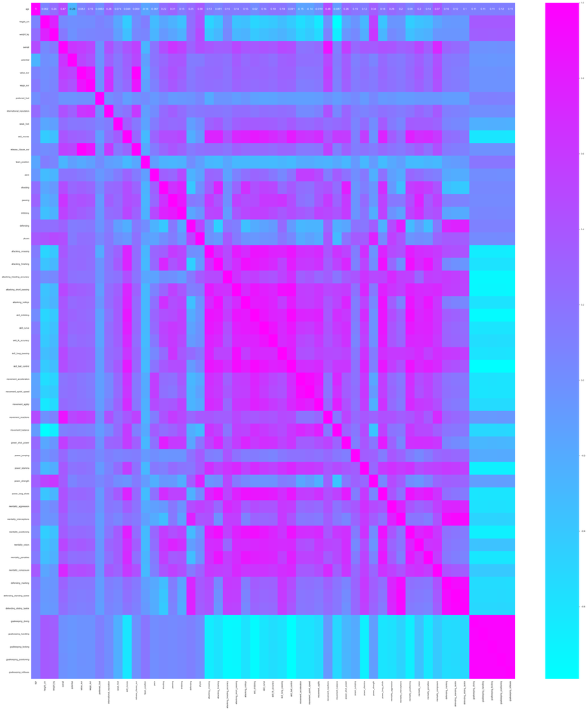

```python
# Plot hitmap for better visualisation
plt.figure(figsize=(40,45))
sns.heatmap(data.corr(),annot=True,cmap='cool')
plt.show()
```

From the above heatmap is very difficult to find highly correalted feature so we are create a python code to check the highly corelated feature

```python
# To get highly corelated feature
pd.set_option('display.max_rows',None)
corrmat = data.corr()
corrmat = corrmat.abs().unstack()
corrmat = corrmat.sort_values(ascending=False)
corrmat = corrmat [corrmat >= 0.9] # Set threshold 0.9
corrmat = corrmat [corrmat < 1]
corrmat = pd.DataFrame(corrmat).reset_index()
corrmat.columns = ['feature1','feature2','corr']
corrmat
```

|  | feature1 | feature2 | corr |
| --- | --- | --- | --- |
| 0 | release_clause_eur | value_eur | 0.979233 |
| 1 | value_eur | release_clause_eur | 0.979233 |
| 2 | defending_sliding_tackle | defending_standing_tackle | 0.975808 |
| 3 | defending_standing_tackle | defending_sliding_tackle | 0.975808 |
| 4 | goalkeeping_diving | goalkeeping_reflexes | 0.973922 |
| 5 | goalkeeping_reflexes | goalkeeping_diving | 0.973922 |
| 6 | goalkeeping_handling | goalkeeping_diving | 0.971330 |
| 7 | goalkeeping_diving | goalkeeping_handling | 0.971330 |
| 8 | goalkeeping_reflexes | goalkeeping_handling | 0.971244 |
| 9 | goalkeeping_handling | goalkeeping_reflexes | 0.971244 |
| 10 | goalkeeping_diving | goalkeeping_positioning | 0.971218 |
| 11 | goalkeeping_positioning | goalkeeping_diving | 0.971218 |
| 12 | goalkeeping_positioning | goalkeeping_reflexes | 0.971060 |
| 13 | goalkeeping_reflexes | goalkeeping_positioning | 0.971060 |
| 14 | goalkeeping_handling | goalkeeping_positioning | 0.970517 |
| 15 | goalkeeping_positioning | goalkeeping_handling | 0.970517 |
| 16 | goalkeeping_reflexes | goalkeeping_kicking | 0.967866 |
| 17 | goalkeeping_kicking | goalkeeping_reflexes | 0.967866 |
| 18 | goalkeeping_diving | goalkeeping_kicking | 0.967057 |
| 19 | goalkeeping_kicking | goalkeeping_diving | 0.967057 |
| 20 | goalkeeping_handling | goalkeeping_kicking | 0.966508 |
| 21 | goalkeeping_kicking | goalkeeping_handling | 0.966508 |
| 22 | goalkeeping_positioning | goalkeeping_kicking | 0.966061 |
| 23 | goalkeeping_kicking | goalkeeping_positioning | 0.966061 |
| 24 | defending_standing_tackle | mentality_interceptions | 0.945287 |
| 25 | mentality_interceptions | defending_standing_tackle | 0.945287 |
| 26 | skill_ball_control | skill_dribbling | 0.943461 |
| 27 | skill_dribbling | skill_ball_control | 0.943461 |
| 28 | mentality_interceptions | defending_sliding_tackle | 0.933894 |
| 29 | defending_sliding_tackle | mentality_interceptions | 0.933894 |
| 30 | movement_sprint_speed | movement_acceleration | 0.923721 |
| 31 | movement_acceleration | movement_sprint_speed | 0.923721 |
| 32 | defending_standing_tackle | defending_marking | 0.918593 |
| 33 | defending_marking | defending_standing_tackle | 0.918593 |
| 34 | skill_ball_control | attacking_short_passing | 0.917721 |
| 35 | attacking_short_passing | skill_ball_control | 0.917721 |
| 36 | defending_sliding_tackle | defending_marking | 0.909153 |
| 37 | defending_marking | defending_sliding_tackle | 0.909153 |
| 38 | mentality_interceptions | defending_marking | 0.907401 |
| 39 | defending_marking | mentality_interceptions | 0.907401 |
| 40 | skill_dribbling | mentality_positioning | 0.904501 |
| 41 | mentality_positioning | skill_dribbling | 0.904501 |

DROP HIGHLY CORRELATED FEATURE

```python
data.drop(['release_clause_eur','defending_standing_tackle','goalkeeping_diving','goalkeeping_handling',
           'goalkeeping_positioning','goalkeeping_reflexes','mentality_interceptions','skill_ball_control',
           'movement_sprint_speed','defending_marking','mentality_positioning','attacking_short_passing'],axis=1,inplace=True)
```

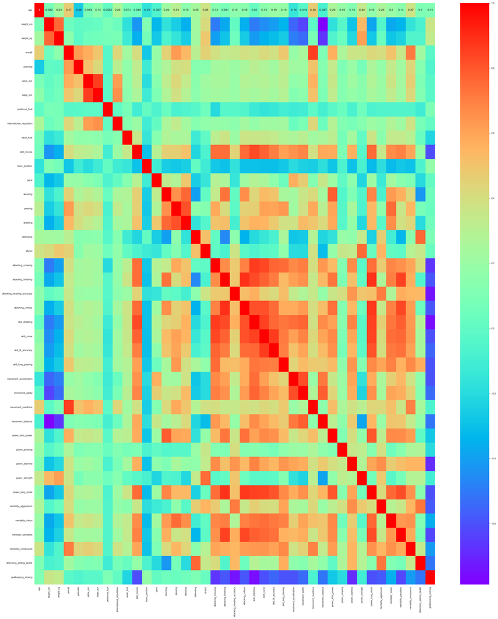

```python
# Plot hitmap for after drop highly correlated feature better visualisation
plt.figure(figsize=(30,35))
sns.heatmap(data.corr(),annot=True,cmap='rainbow')
plt.show()
```

# 3.CHECKING DUPLICATES

```python
data.duplicated().sum()
```

```
0
```

Their is no duplicate present in data

# 4.PRINCIPLE COMPONENT ANALYSIS(PCA)

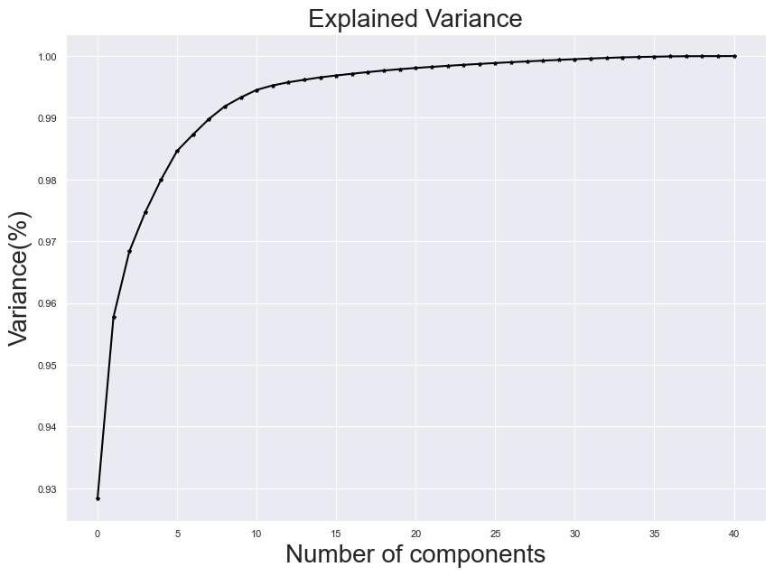

```python
# Step:1 Getting optimal value of pca
from sklearn.decomposition import PCA
pca = PCA() # Object creation
principlecomponents = pca.fit_transform(data) # Fitting the data
plt.figure(figsize=(10,7))
sns.set_style('darkgrid')
plt.plot(np.cumsum(pca.explained_variance_ratio_),marker='*',color='k') #plot the variance ratio
plt.xlabel('Number of components',fontsize=20)
plt.ylabel('Variance(%)',fontsize=20) # for each componant
plt.title('Explained Variance',fontsize=20)
plt.show()
```

Here we are select 10 components because less varaince loss

```python
# Step:2 Select the components
pca = PCA(n_components=10)
fifa = pca.fit_transform(data)

# Step:3 Make new dataframe
principle_df = pd.DataFrame(data=fifa,columns=['pca1','pca2','pca3','pca4','pca5','pca6','pca7','pca8','pca9','pca10'])
principle_df.head()
```

|  | pca1 | pca2 | pca3 | pca4 | pca5 | pca6 | pca7 | pca8 | pca9 | pca10 |
| --- | --- | --- | --- | --- | --- | --- | --- | --- | --- | --- |
| 0 | 15.461256 | 2.015093 | -0.120716 | 1.421170 | 0.341254 | 2.739364 | 1.537915 | -0.620566 | 1.301976 | -0.046891 |
| 1 | 14.498249 | 2.574933 | -0.087257 | 1.623457 | 1.366016 | 2.168913 | 1.613293 | 0.292836 | 1.265556 | -0.274000 |
| 2 | 8.528416 | 3.407803 | -0.926819 | 1.136359 | 1.184205 | 2.325616 | 1.935474 | -0.107827 | 1.244950 | 0.241178 |
| 3 | -1.789442 | -1.354069 | -0.828835 | 0.997627 | 0.682168 | 1.649941 | 0.772422 | -0.284516 | 0.193660 | -0.255402 |
| 4 | 14.445248 | 1.825999 | -0.363462 | 0.916801 | 1.017116 | 1.766322 | 1.135604 | -0.397063 | 1.032422 | 0.079791 |

# MODEL CREATION

AIM

Create a cluster on data Get best sillhoutte score, range of sillhoutte score between -1 to +1

```python
#Step:1 Define independant veriable
X = principle_df
X.head()
```

|  | pca1 | pca2 | pca3 | pca4 | pca5 | pca6 | pca7 | pca8 | pca9 | pca10 |
| --- | --- | --- | --- | --- | --- | --- | --- | --- | --- | --- |
| 0 | 15.461256 | 2.015093 | -0.120716 | 1.421170 | 0.341254 | 2.739364 | 1.537915 | -0.620566 | 1.301976 | -0.046891 |
| 1 | 14.498249 | 2.574933 | -0.087257 | 1.623457 | 1.366016 | 2.168913 | 1.613293 | 0.292836 | 1.265556 | -0.274000 |
| 2 | 8.528416 | 3.407803 | -0.926819 | 1.136359 | 1.184205 | 2.325616 | 1.935474 | -0.107827 | 1.244950 | 0.241178 |
| 3 | -1.789442 | -1.354069 | -0.828835 | 0.997627 | 0.682168 | 1.649941 | 0.772422 | -0.284516 | 0.193660 | -0.255402 |
| 4 | 14.445248 | 1.825999 | -0.363462 | 0.916801 | 1.017116 | 1.766322 | 1.135604 | -0.397063 | 1.032422 | 0.079791 |

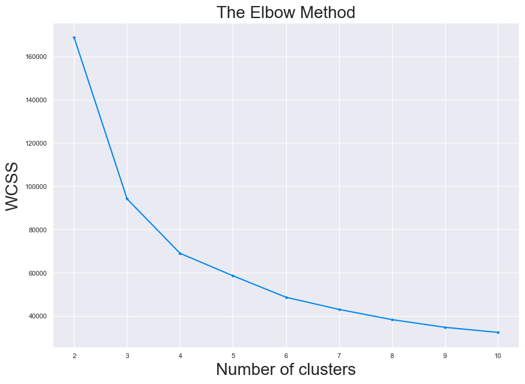

```python
# Step:3 Initalize the k value
from sklearn.cluster import KMeans
kmeans = KMeans() # Object creation
wcss = [] # Create empty list

for i in range(2,11):
    kmeans = KMeans(n_clusters=i,random_state=42)
    kmeans = kmeans.fit(X)
    wcss.append(kmeans.inertia_)
plt.figure(figsize=(10,7))
plt.plot(range(2,11),wcss,marker='*')
plt.title('The Elbow Method',fontsize=20)
plt.xlabel('Number of clusters',fontsize=20)
plt.ylabel('WCSS',fontsize=20)
plt.show()
```

From above plot we are select 3 cluster because of odd no and more variance

```python
# Step:3 initalize the cluster
kmeans = KMeans(n_clusters=3,random_state=45)

# Step:4 Fitting the data
kmeans.fit(X)

# Step:5  Get labels
kmeans.labels_

# Step:6 Print dataset with labels
principle_df['cluster'] = pd.DataFrame(kmeans.labels_)
principle_df.head()
```

|  | pca1 | pca2 | pca3 | pca4 | pca5 | pca6 | pca7 | pca8 | pca9 | pca10 | cluster |
| --- | --- | --- | --- | --- | --- | --- | --- | --- | --- | --- | --- |
| 0 | 15.461256 | 2.015093 | -0.120716 | 1.421170 | 0.341254 | 2.739364 | 1.537915 | -0.620566 | 1.301976 | -0.046891 | 2 |
| 1 | 14.498249 | 2.574933 | -0.087257 | 1.623457 | 1.366016 | 2.168913 | 1.613293 | 0.292836 | 1.265556 | -0.274000 | 2 |
| 2 | 8.528416 | 3.407803 | -0.926819 | 1.136359 | 1.184205 | 2.325616 | 1.935474 | -0.107827 | 1.244950 | 0.241178 | 1 |
| 3 | -1.789442 | -1.354069 | -0.828835 | 0.997627 | 0.682168 | 1.649941 | 0.772422 | -0.284516 | 0.193660 | -0.255402 | 0 |
| 4 | 14.445248 | 1.825999 | -0.363462 | 0.916801 | 1.017116 | 1.766322 | 1.135604 | -0.397063 | 1.032422 | 0.079791 | 2 |

```python
# Step:7 initalize the centroids
kmeans.cluster_centers_
```

```
array([[-3.03251217e+00, -6.90993259e-02, -1.11911340e-02,
         4.23092358e-04,  4.01314971e-03,  2.65526517e-03,
         6.82649258e-03,  1.22633783e-02,  8.38487969e-03,
         1.66215656e-03],
       [ 4.43843567e+00,  3.74492120e-01,  5.74574061e-02,
        -1.21601954e-03, -3.33722496e-02, -2.68969098e-04,
        -2.04301567e-02, -5.31859328e-02, -5.23230612e-02,
        -7.88468953e-03],
       [ 1.34760598e+01, -2.34704589e-01, -3.16812647e-02,
        -6.97403449e-04,  3.66660483e-02, -1.89688721e-02,
        -9.64712652e-03,  1.53403015e-02,  4.21163067e-02,
         3.41890146e-03]])
```

# MODEL EVALUATION

SILHOUETTE SCORE

1.silhouette score range(-1 to +1) 2.+1 ---> Samles are very far from cluster 3.0 ---> Samples close to dicision boundry 4.-1 ---> Samples are assign to wrong cluster

```python
# Step:8 Create a new veriable assign to labels
labels = kmeans.labels_
labels

# Step:9 import library to evaluate the model
from sklearn.metrics import silhouette_score
silhou_score = silhouette_score(X,labels)
print("Silhouette Score:",silhou_score)
```

```
Silhouette Score: 0.6162904767463244
```

# CONCLUSION:

CLUSTER

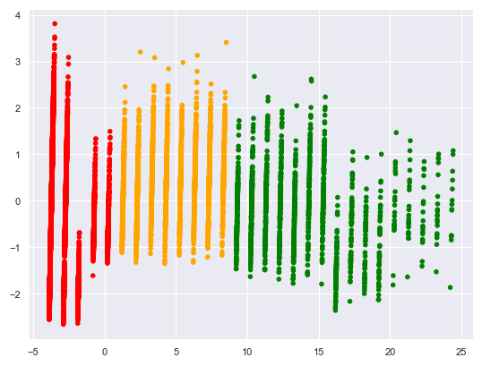

```python
import matplotlib.pyplot as plt
import numpy as np

# Assuming principle_df is your DataFrame and kmeans.labels_ are your cluster labels
color = np.array(['red', 'orange', 'green'])

# Scatter plot using matplotlib
plt.scatter(principle_df.pca1, principle_df.pca2, c=color[kmeans.labels_])

plt.show()
```

# MODEL SAVING

```python
# Model saving using pickle
import pickle
file = open("kmeans_clustering_model.pkl","wb")
pickle.dump(kmeans,file)
```